# Ebola Contact Risk Analysis

Secondary attack rates and contact patterns by exposure level

25 June 2026

```r
library(tidyverse)
library(readxl)
library(lme4)
library(broom.mixed)
```

# Overview

This document presents a systematic analysis of secondary attack rates (SAR) and contact patterns by exposure level, drawing on data extracted from published Ebola outbreak studies. The analysis proceeds in four stages:

1. **Data preparation** — standardising heterogeneous contact definitions across studies to a common canonical hierarchy
2. **SAR estimation** — fitting a multivariable binomial logistic regression to estimate disease risk by exposure level
3. **Contact rate estimation** — fitting a negative binomial model to estimate contacts per index case by exposure level
4. **Risk threshold analysis** — evaluating sensitivity and specificity of alternative high-risk contact definitions using a simulation

# 1. Canonical Exposure Hierarchy

Contact definitions vary substantially across studies. Raw definitions were mapped to a five-level canonical hierarchy ordered from lowest to highest transmission risk. The two lowest-risk classes (no/minimal contact; indirect contact only) were merged into a single reference category because both are sparsely reported and share the defining characteristic of no direct physical contact with the index case.

```r
canonical_levels <- c(
  "No direct physical contact",                         # Classes 0+1 — reference
  "Direct physical contact - no fluids and no nursing", # Class 2
  "Nursing care - no body fluids",                      # Class 3
  "Body fluid contact",                                 # Class 4
  "Handled corpse"                                      # Class 5
)

canonical_levels_sensitivity <- c(
  "No/minimal contact",
  "Indirect contact only",
  "Direct physical contact - no fluids and no nursing",
  "Nursing care - no body fluids",
  "Body fluid contact",
  "Handled corpse"
)

reference_level      <- canonical_levels[1]
non_reference_levels <- canonical_levels[-1]

tibble(
  Class     = c("Reference", paste("Class", 2:5)),
  Label     = canonical_levels,
  `Key criterion` = c(
    "No direct physical contact with index case",
    "Touched index case; no fluids, no nursing",
    "Actively cared for index case; no documented fluid exposure",
    "Documented exposure to blood or body fluids",
    "Participated in funeral preparation or burial"
  )
)
```

| Class | Label | Key criterion |
| --- | --- | --- |
| Reference | No direct physical contact | No direct physical contact with index case |
| Class 2 | Direct physical contact - no fluids and no nursing | Touched index case; no fluids, no nursing |
| Class 3 | Nursing care - no body fluids | Actively cared for index case; no documented fluid exposure |
| Class 4 | Body fluid contact | Documented exposure to blood or body fluids |
| Class 5 | Handled corpse | Participated in funeral preparation or burial |

# 2. Data Loading and Cleaning

```r
raw <- read_excel(here::here("data", "sar_extraction.xlsx"), sheet = "data_me")
mapping_raw <- read_excel(here::here("data", "sar_extraction.xlsx"),
                          sheet = "exposure_mapping")

dat <- raw %>%
  mutate(
    numerator           = as.integer(numerator),
    denominator         = as.integer(denominator),
    num_index           = as.integer(num_index),
    year                = as.character(year),
    study_id            = paste(first_author, year_publication, location, sep = "_"),
    sar_observed        = numerator / denominator,
    uninfected_contacts = denominator - numerator
  ) %>%
  filter(
    !is.na(numerator),
    !is.na(denominator),
    denominator > 0,
    numerator <= denominator,
    include == TRUE
  )

dat %>%
  group_by(first_author, year_publication, location) %>%
  summarise(
    n_definitions = length(unique(definition_contact_me)),
    total_contacts = sum(denominator),
    total_cases    = sum(numerator),
    .groups = "drop"
  ) %>%
  rename(Author = first_author, Year = year_publication,
         Location = location, `Contact definitions` = n_definitions,
         `Total contacts` = total_contacts, `Total cases` = total_cases)
```

| Author | Year | Location | Contact definitions | Total contacts | Total cases |
| --- | --- | --- | --- | --- | --- |
| Baron | 1983 | Nzara; Yambio | 3 | 130 | 27 |
| Bower | 2016 | Kerry Town | 6 | 809 | 347 |
| Gayedyu-Dennis | 2023 | Multiple (7 of 15 counties in Liberia) | 3 | 1909 | 222 |
| Henao-Restrepo | 2017 | Basse-Guinée | 2 | 412 | 13 |
| International Commission | 1978 | Maridi | 2 | 96 | 48 |
| Jezek | 1999 | Sud-Ubangi | 2 | 188 | 28 |
| Reaves | 2014 | Firestone District | 2 | 233 | 21 |
| Reichler | 2018 | Freetown | 4 | 837 | 83 |

# 3. Exposure Mapping

Raw contact definitions were mapped to canonical levels via a manually curated mapping table. Where a definition spanned multiple canonical levels (e.g. “high-risk” covering both body fluid contact and corpse handling), fractional encoding was applied.

```r
mapping_long <- mapping_raw %>%
  pivot_longer(
    cols      = starts_with("exposure"),
    names_to  = "exposurenum",
    values_to = "exposure"
  ) %>%
  dplyr::select(-exposurenum) %>%
  filter(!is.na(exposure)) %>%
  mutate(
    exposure = case_when(
      exposure %in% c("No/minimal contact", "Indirect contact only") ~
        "No direct physical contact",
      TRUE ~ exposure
    )
  )

mapping_table <- mapping_long %>%
  distinct(first_author, definition_contact_me, exposure, .keep_all = TRUE) %>%
  group_by(first_author, definition_contact_me) %>%
  mutate(
    n_canonical    = n(),
    is_combined    = n_canonical > 1,
    covered_levels = list(exposure)
  ) %>%
  ungroup()

# Validate
unrecognised <- mapping_table %>%
  filter(!exposure %in% canonical_levels) %>%
  distinct(exposure)

if (nrow(unrecognised) > 0) {
  stop("Unrecognised canonical levels: ", paste(unrecognised$exposure, collapse = ", "))
}

mapping_table %>%
  dplyr::select(first_author, definition_contact_me, exposure, is_combined) %>%
  rename(Author = first_author, `Raw definition` = definition_contact_me,
         `Canonical level` = exposure, Combined = is_combined)
```

| Author | Raw definition | Canonical level | Combined |
| --- | --- | --- | --- |
| Baron | not direct contact | No direct physical contact | FALSE |
| Baron | direct contact + nursing care | Nursing care - no body fluids | TRUE |
| Baron | direct contact + nursing care | Body fluid contact | TRUE |
| Baron | direct contact but NO nursing care | Direct physical contact - no fluids and no nursing | FALSE |
| Henao-Restrepo | High-risk contacts were defined as being in close physical contact with the patient’s body or body fluids, linen, or clothes | Direct physical contact - no fluids and no nursing | TRUE |
| Henao-Restrepo | High-risk contacts were defined as being in close physical contact with the patient’s body or body fluids, linen, or clothes | Nursing care - no body fluids | TRUE |
| Henao-Restrepo | High-risk contacts were defined as being in close physical contact with the patient’s body or body fluids, linen, or clothes | Body fluid contact | TRUE |
| Henao-Restrepo | High-risk contacts were defined as being in close physical contact with the patient’s body or body fluids, linen, or clothes | Handled corpse | TRUE |
| Henao-Restrepo | As below - but not high risk… | No direct physical contact | FALSE |
| Jezek | Provided care | Direct physical contact - no fluids and no nursing | TRUE |
| Jezek | Provided care | Nursing care - no body fluids | TRUE |
| Jezek | Provided care | Body fluid contact | TRUE |
| Jezek | Did not provide care | No direct physical contact | FALSE |
| Reichler | Household contact with NO direct physical contact to index case | No direct physical contact | FALSE |
| Reichler | Household contact who had direct physical contact with the index and NO nursing care | Direct physical contact - no fluids and no nursing | FALSE |
| Reichler | Household contact who had direct physical contact with the index and provided nursing care (with no or some protection) but NO contact with body fluids | Nursing care - no body fluids | FALSE |
| Reichler | Household contact who had direct physical contact with the index and provided nursing care (with no or some protection) andcontact with body fluids | Body fluid contact | FALSE |
| Reaves | High-risk exposure identified as a percutaneous or mucous membrane exposure to, or direct skin contact with blood or body fluids of an Ebola patient or a corpse in Liberia without appropriate PPE | Direct physical contact - no fluids and no nursing | TRUE |
| Reaves | High-risk exposure identified as a percutaneous or mucous membrane exposure to, or direct skin contact with blood or body fluids of an Ebola patient or a corpse in Liberia without appropriate PPE | Nursing care - no body fluids | TRUE |
| Reaves | High-risk exposure identified as a percutaneous or mucous membrane exposure to, or direct skin contact with blood or body fluids of an Ebola patient or a corpse in Liberia without appropriate PPE | Body fluid contact | TRUE |
| Reaves | High-risk exposure identified as a percutaneous or mucous membrane exposure to, or direct skin contact with blood or body fluids of an Ebola patient or a corpse in Liberia without appropriate PPE | Handled corpse | TRUE |
| Reaves | Low-risk exposure defined as a household contact that did not involve providing care to an Ebola patient or having close contact with an Ebola patient in healthcare facilities or in the community that… | No direct physical contact | FALSE |
| Gayedyu-Dennis | Contact with body fluids of index | Body fluid contact | FALSE |
| Gayedyu-Dennis | Slept or ate in the same room, contact with clothing, direct physical contact | Direct physical contact - no fluids and no nursing | FALSE |
| Gayedyu-Dennis | No physical contact | No direct physical contact | FALSE |
| International Commission | Nursed the patient | Nursing care - no body fluids | TRUE |
| International Commission | Nursed the patient | Body fluid contact | TRUE |
| International Commission | Did not provide care | Direct physical contact - no fluids and no nursing | TRUE |
| International Commission | Did not provide care | No direct physical contact | TRUE |
| Bower | Handled corpse | Handled corpse | FALSE |
| Bower | Handled fluids | Body fluid contact | FALSE |
| Bower | Direct wet contact | Nursing care - no body fluids | FALSE |
| Bower | Direct dry contact | Direct physical contact - no fluids and no nursing | FALSE |
| Bower | Indirect contact | No direct physical contact | FALSE |
| Bower | Minimal/no contact | No direct physical contact | FALSE |

# 4. Join Mapping onto Data

```r
dat_mapped <- dat %>%
  left_join(
    mapping_table %>%
      dplyr::select(first_author, definition_contact_me, exposure,
                    is_combined, n_canonical, covered_levels),
    by           = c("first_author", "definition_contact_me"),
    relationship = "many-to-many"
  )

unmapped <- dat_mapped %>%
  filter(is.na(exposure)) %>%
  distinct(first_author, definition_contact_me)

if (nrow(unmapped) > 0) {
  warning("Unmapped rows excluded: ",
          paste(unmapped$first_author, unmapped$definition_contact_me,
                sep = " | ", collapse = "; "))
  dat_mapped <- dat_mapped %>% filter(!is.na(exposure))
}
```

# 5. Fractional Encoding

```r
# Fully disaggregated studies
fully_disaggregated_studies <- dat_mapped %>%
  group_by(study_id) %>%
  summarise(any_combined = any(is_combined), .groups = "drop") %>%
  filter(!any_combined) %>%
  pull(study_id)

# Study-level proportions
study_level_props <- dat_mapped %>%
  filter(study_id %in% fully_disaggregated_studies) %>%
  group_by(study_id, exposure) %>%
  summarise(n_exposure = sum(denominator), .groups = "drop") %>%
  group_by(study_id) %>%
  mutate(
    total_n    = sum(n_exposure),
    study_prop = n_exposure / total_n,
    n_levels_observed = n()
  ) %>%
  ungroup()

# Global reference distribution
ref_distribution <- study_level_props %>%
  group_by(exposure) %>%
  summarise(
    ref_prop  = weighted.mean(study_prop, total_n),
    n_studies = n(),
    .groups   = "drop"
  ) %>%
  complete(exposure = canonical_levels, fill = list(ref_prop = 0, n_studies = 0)) %>%
  mutate(
    ref_prop = ref_prop / sum(ref_prop),
    exposure = factor(exposure, levels = canonical_levels)
  ) %>%
  arrange(exposure)

ref_distribution %>%
  rename(`Canonical level` = exposure,
         `Reference proportion` = ref_prop,
         `N studies contributing` = n_studies) %>%
  mutate(`Reference proportion` = scales::percent(`Reference proportion`, accuracy = 0.1))
```

| Canonical level | Reference proportion | N studies contributing |
| --- | --- | --- |
| No direct physical contact | 24.3% | 3 |
| Direct physical contact - no fluids and no nursing | 23.9% | 3 |
| Nursing care - no body fluids | 17.6% | 2 |
| Body fluid contact | 26.7% | 3 |
| Handled corpse | 7.5% | 1 |

```r
dat_fractions <- dat_mapped %>%
  left_join(ref_distribution %>% dplyr::select(exposure, ref_prop), by = "exposure") %>%
  mutate(fraction_raw = if_else(!is_combined, 1, ref_prop)) %>%
  group_by(study_id, definition_contact_me) %>%
  mutate(
    fraction_sum     = sum(fraction_raw),
    fraction_contact = if_else(fraction_sum > 0, fraction_raw / fraction_sum, 1 / n())
  ) %>%
  ungroup() %>%
  mutate(
    numerator_adj           = numerator   * fraction_contact,
    denominator_adj         = denominator * fraction_contact,
    uninfected_contacts_adj = denominator_adj - numerator_adj
  )

# Fraction check
fraction_check <- dat_fractions %>%
  group_by(study_id, definition_contact_me) %>%
  summarise(fraction_sum = sum(fraction_contact), .groups = "drop") %>%
  filter(abs(fraction_sum - 1) > 1e-6)

if (nrow(fraction_check) == 0) {
  cat("Fraction check passed: all fractions sum to 1 within study x definition.")
}
```

```
## Fraction check passed: all fractions sum to 1 within study x definition.
```

# 6. Model Data

Note that at the moment I round the adjusted numerators to the nearest integer so that what I am passing into the Binomial logistic regression is an integer. I need to figure out if there is a more sophisticated way of doing this such as by using an approximation using a Gamma function.

```r
model_data <- dat_fractions %>%
  group_by(study_id, exposure) %>%
  summarise(
    numerator_adj           = round(sum(numerator_adj), digits = 0),
    denominator_adj         = round(sum(denominator_adj), digits = 0),
    uninfected_contacts_adj = round(sum(uninfected_contacts_adj), digits = 0),
    num_index               = first(num_index),
    .groups                 = "drop") %>%
  mutate(exposure  = factor(exposure, levels = canonical_levels),
    exposure  = relevel(exposure, ref = reference_level)) %>%
  filter(denominator_adj > 0)

# Wide design matrix for inspection
design_matrix_wide <- dat_fractions %>%
  group_by(study_id, exposure) %>%
  summarise(
    numerator_adj           = round(sum(numerator_adj), digits = 0),
    denominator_adj         = round(sum(denominator_adj), digits = 0),
    uninfected_contacts_adj = round(sum(uninfected_contacts_adj), digits = 0),
    fraction_contact        = min(sum(fraction_contact), 1),
    .groups = "drop"
  ) %>%
  pivot_wider(
    names_from  = exposure,
    values_from = fraction_contact,
    values_fill = 0,
    id_cols     = c(study_id, numerator_adj, denominator_adj, uninfected_contacts_adj)
  ) %>%
  dplyr::select(-any_of(reference_level)) %>%
  dplyr::select(study_id, numerator_adj, denominator_adj,
                uninfected_contacts_adj, any_of(non_reference_levels))

design_matrix_wide
```

| study_id | numerator_adj | denominator_adj | uninfected_contacts_adj | Direct physical contact - no fluids and no nursing | Nursing care - no body fluids | Body fluid contact | Handled corpse |
| --- | --- | --- | --- | --- | --- | --- | --- |
| Baron_1983_Nzara; Yambio | 14 | 36 | 22 | 0.0000000 | 0.0000000 | 0.6032905 | 0.0000000 |
| Baron_1983_Nzara; Yambio | 3 | 26 | 23 | 1.0000000 | 0.0000000 | 0.0000000 | 0.0000000 |
| Baron_1983_Nzara; Yambio | 0 | 44 | 44 | 0.0000000 | 0.0000000 | 0.0000000 | 0.0000000 |
| Baron_1983_Nzara; Yambio | 10 | 24 | 14 | 0.0000000 | 0.3967095 | 0.0000000 | 0.0000000 |
| Bower_2016_Kerry Town | 73 | 120 | 47 | 0.0000000 | 0.0000000 | 1.0000000 | 0.0000000 |
| Bower_2016_Kerry Town | 47 | 125 | 78 | 1.0000000 | 0.0000000 | 0.0000000 | 0.0000000 |
| Bower_2016_Kerry Town | 60 | 72 | 12 | 0.0000000 | 0.0000000 | 0.0000000 | 1.0000000 |
| Bower_2016_Kerry Town | 21 | 195 | 174 | 0.0000000 | 0.0000000 | 0.0000000 | 0.0000000 |
| Bower_2016_Kerry Town | 146 | 297 | 151 | 0.0000000 | 1.0000000 | 0.0000000 | 0.0000000 |
| Gayedyu-Dennis_2023_Multiple (7 of 15 counties in Liberia) | 117 | 888 | 771 | 0.0000000 | 0.0000000 | 1.0000000 | 0.0000000 |
| Gayedyu-Dennis_2023_Multiple (7 of 15 counties in Liberia) | 81 | 746 | 665 | 1.0000000 | 0.0000000 | 0.0000000 | 0.0000000 |
| Gayedyu-Dennis_2023_Multiple (7 of 15 counties in Liberia) | 24 | 275 | 251 | 0.0000000 | 0.0000000 | 0.0000000 | 0.0000000 |
| Henao-Restrepo_2017_Basse-Guinée | 2 | 81 | 79 | 0.0000000 | 0.0000000 | 0.3525476 | 0.0000000 |
| Henao-Restrepo_2017_Basse-Guinée | 2 | 73 | 71 | 0.3160337 | 0.0000000 | 0.0000000 | 0.0000000 |
| Henao-Restrepo_2017_Basse-Guinée | 1 | 23 | 22 | 0.0000000 | 0.0000000 | 0.0000000 | 0.0995917 |
| Henao-Restrepo_2017_Basse-Guinée | 7 | 181 | 174 | 0.0000000 | 0.0000000 | 0.0000000 | 0.0000000 |
| Henao-Restrepo_2017_Basse-Guinée | 1 | 54 | 52 | 0.0000000 | 0.2318269 | 0.0000000 | 0.0000000 |
| International Commission_1978_Maridi | 24 | 29 | 5 | 0.0000000 | 0.0000000 | 0.6032905 | 0.0000000 |
| International Commission_1978_Maridi | 4 | 24 | 19 | 0.4965381 | 0.0000000 | 0.0000000 | 0.0000000 |
| International Commission_1978_Maridi | 5 | 24 | 20 | 0.0000000 | 0.0000000 | 0.0000000 | 0.0000000 |
| International Commission_1978_Maridi | 15 | 19 | 4 | 0.0000000 | 0.3967095 | 0.0000000 | 0.0000000 |
| Jezek_1999_Sud-Ubangi | 4 | 20 | 16 | 0.0000000 | 0.0000000 | 0.3915419 | 0.0000000 |
| Jezek_1999_Sud-Ubangi | 3 | 18 | 15 | 0.3509894 | 0.0000000 | 0.0000000 | 0.0000000 |
| Jezek_1999_Sud-Ubangi | 19 | 137 | 118 | 0.0000000 | 0.0000000 | 0.0000000 | 0.0000000 |
| Jezek_1999_Sud-Ubangi | 2 | 13 | 11 | 0.0000000 | 0.2574687 | 0.0000000 | 0.0000000 |
| Reaves_2014_Firestone District | 7 | 26 | 19 | 0.0000000 | 0.0000000 | 0.3525476 | 0.0000000 |
| Reaves_2014_Firestone District | 7 | 23 | 17 | 0.3160337 | 0.0000000 | 0.0000000 | 0.0000000 |
| Reaves_2014_Firestone District | 2 | 7 | 5 | 0.0000000 | 0.0000000 | 0.0000000 | 0.0995917 |
| Reaves_2014_Firestone District | 0 | 159 | 159 | 0.0000000 | 0.0000000 | 0.0000000 | 0.0000000 |
| Reaves_2014_Firestone District | 5 | 17 | 12 | 0.0000000 | 0.2318269 | 0.0000000 | 0.0000000 |
| Reichler_2018_Freetown | 24 | 112 | 88 | 0.0000000 | 0.0000000 | 1.0000000 | 0.0000000 |
| Reichler_2018_Freetown | 13 | 133 | 120 | 1.0000000 | 0.0000000 | 0.0000000 | 0.0000000 |
| Reichler_2018_Freetown | 33 | 548 | 515 | 0.0000000 | 0.0000000 | 0.0000000 | 0.0000000 |
| Reichler_2018_Freetown | 13 | 44 | 31 | 0.0000000 | 1.0000000 | 0.0000000 | 0.0000000 |

# 7. Analysis 1: Secondary Attack Rate by Exposure Level

```r
fit_fixed <- glm(
  cbind(numerator_adj, uninfected_contacts_adj) ~ exposure,
  data   = model_data,
  family = binomial(link = "logit")
)

or_fixed <- broom::tidy(fit_fixed, exponentiate = TRUE, conf.int = TRUE) %>%
  rename(odds_ratio = estimate, ci_lower = conf.low, ci_upper = conf.high) %>%
  mutate(
    term      = str_remove(term, "^exposure"),
    across(c(odds_ratio, ci_lower, ci_upper), ~ round(.x, 2)),
    p.value   = scales::pvalue(p.value)
  )

or_fixed %>%
  rename(Term = term, `Odds ratio` = odds_ratio,
         `CI lower` = ci_lower, `CI upper` = ci_upper,
         `p value` = p.value) %>%
  dplyr::select(Term, `Odds ratio`, `CI lower`, `CI upper`, `p value`)
```

| Term | Odds ratio | CI lower | CI upper | p value |
| --- | --- | --- | --- | --- |
| (Intercept) | 0.07 | 0.06 | 0.09 | <0.001 |
| Direct physical contact - no fluids and no nursing | 2.12 | 1.64 | 2.74 | <0.001 |
| Nursing care - no body fluids | 9.32 | 7.14 | 12.22 | <0.001 |
| Body fluid contact | 3.38 | 2.67 | 4.30 | <0.001 |
| Handled corpse | 21.56 | 13.90 | 33.86 | <0.001 |

```r
pred_grid <- tibble(
  exposure          = factor(canonical_levels, levels = canonical_levels)
)

pred_link <- predict(fit_fixed, newdata = pred_grid, type = "link", se.fit = TRUE)

pred_grid <- pred_grid %>%
  mutate(
    predicted_sar = plogis(pred_link$fit),
    ci_lower      = plogis(pred_link$fit - 1.96 * pred_link$se.fit),
    ci_upper      = plogis(pred_link$fit + 1.96 * pred_link$se.fit)
  )

pred_grid %>%
  mutate(across(c(predicted_sar, ci_lower, ci_upper), ~ scales::percent(.x, accuracy = 0.1))) %>%
  rename(`Exposure level` = exposure, `Predicted SAR` = predicted_sar,
         `CI lower` = ci_lower, `CI upper` = ci_upper)
```

| Exposure level | Predicted SAR | CI lower | CI upper |
| --- | --- | --- | --- |
| No direct physical contact | 7.0% | 5.8% | 8.3% |
| Direct physical contact - no fluids and no nursing | 13.7% | 11.8% | 15.8% |
| Nursing care - no body fluids | 41.1% | 36.7% | 45.6% |
| Body fluid contact | 20.2% | 18.1% | 22.5% |
| Handled corpse | 61.8% | 52.0% | 70.7% |

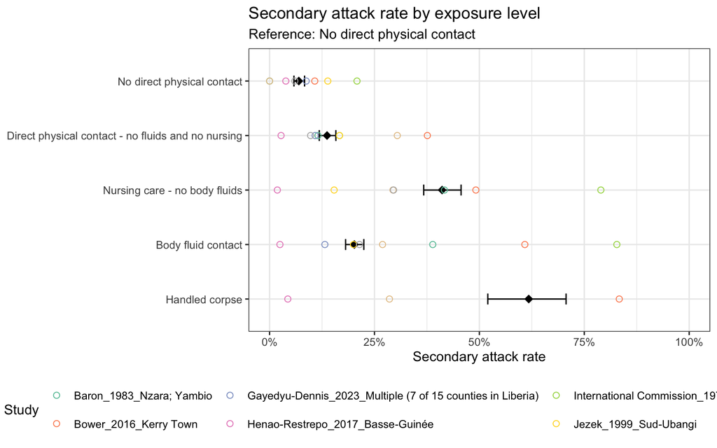

Predicted secondary attack rate by exposure level. Open circles show observed SAR per study.

```r
ggplot() +
  geom_errorbar(data  = pred_grid,
    aes(x = fct_rev(exposure), ymin = ci_lower, ymax = ci_upper),
    width = 0.2) +
  geom_point(data  = pred_grid,
    aes(x = fct_rev(exposure), y = predicted_sar),
    size  = 3, shape = 18) +
  geom_point(data  = model_data,
    aes(x = fct_rev(exposure), y = numerator_adj / denominator_adj, col = study_id),
    size  = 2, shape = 1) +
  scale_y_continuous(labels = scales::percent_format(), limits = c(0, 1)) +
  scale_colour_brewer(palette = "Set2") +
  coord_flip() +
  labs(title    = "Secondary attack rate by exposure level",
    subtitle = paste("Reference:", reference_level),
    x        = NULL,
    y        = "Secondary attack rate",
    col      = "Study") +
  theme_bw() +
  theme(legend.position = "bottom", legend.direction = "horizontal")
```

```r
ggsave(here::here("plots", "sar_by_exposure.png"),
                  dpi = 500, width = 30, height = 20, units = "cm")
```

# 8. Analysis 2: Contacts per Index Case

The number of contacts per index case was modelled using a negative binomial regression with `log(num_index)` as an offset, converting total contact counts to rates per index case. This accounts for variation in the number of index cases across studies. The negative binomial distribution was preferred over Poisson to accommodate overdispersion — heterogeneity in the contact burden across index cases.

```r
contact_data <- dat_mapped %>%
  group_by(study_id, exposure) %>%
  summarise(
    n_contacts = sum(denominator),
    num_index  = first(num_index),
    .groups    = "drop"
  ) %>%
  filter(!is.na(num_index), num_index > 0) %>%
  mutate(
    exposure  = factor(exposure, levels = canonical_levels),
    exposure  = relevel(exposure, ref = reference_level),
    log_index = log(num_index)
  )

contact_data_overall <- contact_data %>%
  group_by(study_id, num_index, log_index) %>%
  summarise(n_contacts = sum(n_contacts), .groups = "drop")

fit_nb_overall <- MASS::glm.nb(
  n_contacts ~ offset(log_index),
  data = contact_data_overall
)

nb_overall_tidy <- broom::tidy(fit_nb_overall, conf.int = TRUE, exponentiate = TRUE)

overall_rate <- tibble(
  estimate = nb_overall_tidy$estimate[nb_overall_tidy$term == "(Intercept)"],
  ci_lower = nb_overall_tidy$conf.low[nb_overall_tidy$term == "(Intercept)"],
  ci_upper = nb_overall_tidy$conf.high[nb_overall_tidy$term == "(Intercept)"],
  theta    = fit_nb_overall$theta
)

cat(sprintf(
  "Estimated contacts per index case: %.1f (95%% CI %.1f-%.1f)\nDispersion parameter (theta): %.2f",
  overall_rate$estimate, overall_rate$ci_lower, overall_rate$ci_upper, overall_rate$theta
))
```

```
## Estimated contacts per index case: 6.8 (95% CI 5.1-9.4)
## Dispersion parameter (theta): 5.12
```

A dispersion parameter (θ) of 5.12 indicates moderate overdispersion — there is meaningful heterogeneity in the number of contacts generated per index case, but the distribution is not consistent with extreme superspreading (which would produce θ close to 0).

```r
fit_nb_exposure <- MASS::glm.nb(
  n_contacts ~ exposure + offset(log_index),
  data = contact_data
)

pred_contacts <- tibble(
  exposure  = factor(canonical_levels, levels = canonical_levels),
  log_index = 0 # i.e. per index case
)

pred_link_contacts <- predict(fit_nb_exposure, newdata = pred_contacts,
                               type = "link", se.fit = TRUE)

pred_contacts <- pred_contacts %>%
  mutate(
    contacts_per_index = exp(pred_link_contacts$fit),
    ci_lower           = exp(pred_link_contacts$fit - 1.96 * pred_link_contacts$se.fit),
    ci_upper           = exp(pred_link_contacts$fit + 1.96 * pred_link_contacts$se.fit)
  )

pred_contacts %>%
  mutate(across(c(contacts_per_index, ci_lower, ci_upper), ~ round(.x, 1))) %>%
  rename(`Exposure level` = exposure, `Contacts per index case` = contacts_per_index,
         `CI lower` = ci_lower, `CI upper` = ci_upper)
```

| Exposure level | log_index | Contacts per index case | CI lower | CI upper |
| --- | --- | --- | --- | --- |
| No direct physical contact | 0 | 2.2 | 1.5 | 3.2 |
| Direct physical contact - no fluids and no nursing | 0 | 1.3 | 0.9 | 1.9 |
| Nursing care - no body fluids | 0 | 1.6 | 1.1 | 2.4 |
| Body fluid contact | 0 | 1.4 | 1.0 | 2.1 |
| Handled corpse | 0 | 1.1 | 0.6 | 2.0 |

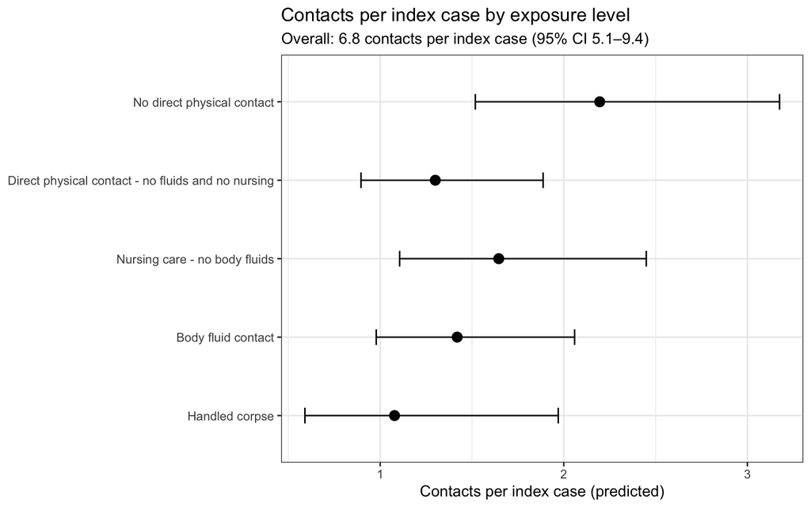

Predicted contacts per index case by exposure level.

```r
pred_contacts %>%
  mutate(exposure = fct_rev(factor(exposure, levels = canonical_levels))) %>%
  ggplot(aes(x = exposure, y = contacts_per_index)) +
  geom_errorbar(aes(ymin = ci_lower, ymax = ci_upper), width = 0.2) +
  geom_point(size = 3) +
  coord_flip() +
  labs(
    title    = "Contacts per index case by exposure level",
    subtitle = sprintf("Overall: %.1f contacts per index case (95%% CI %.1f\u2013%.1f)",
                       overall_rate$estimate, overall_rate$ci_lower, overall_rate$ci_upper),
    x = NULL,
    y = "Contacts per index case (predicted)"
  ) +
  theme_bw()
```

```r
ggsave(here::here("plots", "contacts_by_exposure.png"),
                  dpi = 500, width = 30, height = 20, units = "cm")
```

# 9. Simulation: Contact Line List

Starting with 100 index cases, total contacts per index case were sampled from the fitted negative binomial distribution. Contacts were then allocated across exposure levels using a multinomial draw informed by the reference distribution, and infections were sampled from a binomial distribution using the predicted SAR per exposure level.

```r
set.seed(42)
n_index <- 100

exposure_props <- ref_distribution %>%
  arrange(factor(exposure, levels = canonical_levels)) %>%
  pull(ref_prop)
names(exposure_props) <- canonical_levels

sar_by_exposure <- pred_grid %>%
  arrange(factor(exposure, levels = canonical_levels)) %>%
  pull(predicted_sar)
names(sar_by_exposure) <- canonical_levels

line_list <- map_dfr(1:n_index, function(i) {
  total_contacts <- rnbinom(n = 1, mu = overall_rate$estimate, size = overall_rate$theta)

  if (total_contacts == 0) {
    return(tibble(
      index_case              = sprintf("%03d", i),
      total_contacts          = 0L,
      exposure                = canonical_levels,
      total_contacts_exposure = 0L,
      infected_contacts       = 0L,
      uninfected_contacts     = 0L
    ))
  }

  contacts_per_exposure <- as.integer(
    rmultinom(n = 1, size = total_contacts, prob = exposure_props)
  )
  names(contacts_per_exposure) <- canonical_levels

  infected_per_exposure <- map_int(canonical_levels, function(lvl) {
    n   <- contacts_per_exposure[lvl]
    sar <- sar_by_exposure[lvl]
    if (n == 0) return(0L)
    rbinom(n = 1, size = n, prob = sar)
  })
  names(infected_per_exposure) <- canonical_levels

  tibble(
    index_case              = sprintf("%03d", i),
    total_contacts          = total_contacts,
    exposure                = canonical_levels,
    total_contacts_exposure = as.integer(contacts_per_exposure),
    infected_contacts       = as.integer(infected_per_exposure),
    uninfected_contacts     = as.integer(contacts_per_exposure - infected_per_exposure)
  )
}) %>%
  mutate(exposure = factor(exposure, levels = rev(canonical_levels))) %>%
  arrange(index_case, exposure) %>%
  mutate(exposure = as.character(exposure))

cat(sprintf("Total contacts simulated: %d\n", sum(line_list$total_contacts_exposure)))
```

```
## Total contacts simulated: 703
```

```r
cat(sprintf("Total infected: %d\n", sum(line_list$infected_contacts)))
```

```
## Total infected: 124
```

```r
cat(sprintf("Overall simulated SAR: %.3f\n",
            sum(line_list$infected_contacts) / sum(line_list$total_contacts_exposure)))
```

```
## Overall simulated SAR: 0.176
```

```r
line_list %>%
  filter(total_contacts_exposure > 0) %>%
  head(20) %>%
  rename(`Index case` = index_case, `Total contacts` = total_contacts,
         Exposure = exposure, `Contacts (exposure)` = total_contacts_exposure,
         `Infected` = infected_contacts, `Uninfected` = uninfected_contacts)
```

| Index case | Total contacts | Exposure | Contacts (exposure) | Infected | Uninfected |
| --- | --- | --- | --- | --- | --- |
| 001 | 8 | Handled corpse | 1 | 0 | 1 |
| 001 | 8 | Body fluid contact | 2 | 1 | 1 |
| 001 | 8 | Direct physical contact - no fluids and no nursing | 3 | 0 | 3 |
| 001 | 8 | No direct physical contact | 2 | 0 | 2 |
| 002 | 9 | Handled corpse | 2 | 1 | 1 |
| 002 | 9 | Body fluid contact | 2 | 0 | 2 |
| 002 | 9 | Nursing care - no body fluids | 2 | 2 | 0 |
| 002 | 9 | Direct physical contact - no fluids and no nursing | 2 | 2 | 0 |
| 002 | 9 | No direct physical contact | 1 | 0 | 1 |
| 003 | 8 | Handled corpse | 1 | 0 | 1 |
| 003 | 8 | Body fluid contact | 1 | 0 | 1 |
| 003 | 8 | Nursing care - no body fluids | 1 | 0 | 1 |
| 003 | 8 | Direct physical contact - no fluids and no nursing | 2 | 1 | 1 |
| 003 | 8 | No direct physical contact | 3 | 0 | 3 |
| 004 | 6 | Handled corpse | 2 | 1 | 1 |
| 004 | 6 | Direct physical contact - no fluids and no nursing | 4 | 1 | 3 |
| 005 | 11 | Handled corpse | 2 | 1 | 1 |
| 005 | 11 | Body fluid contact | 3 | 0 | 3 |
| 005 | 11 | Direct physical contact - no fluids and no nursing | 4 | 0 | 4 |
| 005 | 11 | No direct physical contact | 2 | 0 | 2 |

```r
line_list %>%
  group_by(exposure) %>%
  summarise(
    total_contacts = sum(total_contacts_exposure),
    total_infected = sum(infected_contacts),
    simulated_sar  = scales::percent(total_infected / total_contacts, accuracy = 0.1),
    .groups        = "drop"
  ) %>%
  rename(Exposure = exposure, `Total contacts` = total_contacts,
         `Infected` = total_infected, `Simulated SAR` = simulated_sar)
```

| Exposure | Total contacts | Infected | Simulated SAR |
| --- | --- | --- | --- |
| Body fluid contact | 193 | 27 | 14.0% |
| Direct physical contact - no fluids and no nursing | 182 | 21 | 11.5% |
| Handled corpse | 44 | 25 | 56.8% |
| No direct physical contact | 173 | 10 | 5.8% |
| Nursing care - no body fluids | 111 | 41 | 36.9% |

# 10. Risk Threshold Analysis

Four cumulative high-risk contact definitions were evaluated, ranging from corpse handling only (most restrictive) to any direct physical contact (most inclusive). For each definition, sensitivity (proportion of infected contacts captured) and specificity (proportion of uninfected contacts correctly excluded) were computed from the simulated line list along with other important metrics to evaluate the efficiency of the high-risk contact definition.

```r
summary_stats <- function(high_risk_def) {
  summary_table <- line_list %>%
    mutate(contact_class = if_else(exposure %in% high_risk_def,
                                   "high_risk", "non_high_risk")) %>%
    group_by(contact_class) %>%
    summarise(
      cases          = sum(infected_contacts),
      uninfected     = sum(uninfected_contacts),
      total_contacts = sum(total_contacts_exposure)
    ) %>%
    bind_rows(
      summarise(., across(where(is.numeric), sum, na.rm = TRUE),
                across(where(is.character), ~ "total"))
    )

  sar         <- summary_table$cases[summary_table$contact_class == "high_risk"] /
                 summary_table$total_contacts[summary_table$contact_class == "high_risk"]
  sensitivity <- summary_table$cases[summary_table$contact_class == "high_risk"] /
                 summary_table$cases[summary_table$contact_class == "total"]
  specificity <- summary_table$uninfected[summary_table$contact_class == "non_high_risk"] /
                 summary_table$uninfected[summary_table$contact_class == "total"]
  missed_cases <- summary_table$cases[summary_table$contact_class == "non_high_risk"]
  prop_missed  <- missed_cases / summary_table$cases[summary_table$contact_class == "total"]

  list(
    summary_table = summary_table,
    diagnostics   = data.frame(sar, sensitivity, specificity, missed_cases, prop_missed)
  )
}

threshold_definitions <- list(
  "Class 5: Handled corpse only"                  = canonical_levels[5],
  "Class 4-5: Body fluid contact and above"       = canonical_levels[4:5],
  "Class 3-5: Nursing care and above"             = canonical_levels[3:5],
  "Class 2-5: Direct physical contact and above"  = canonical_levels[2:5]
)

results <- imap(threshold_definitions, function(high_risk_def, def_name) {
  res <- summary_stats(high_risk_def)
  list(
    definition  = def_name,
    high_risk   = paste(high_risk_def, collapse = "; "),
    summary     = res$summary_table     %>% mutate(definition = def_name, .before = 1),
    diagnostics = res$diagnostics %>% mutate(definition = def_name, .before = 1)
  )
})

all_summaries  <- map_dfr(results, "summary")
all_diagnostics <- map_dfr(results, "diagnostics")

diagnostics_wide <- all_diagnostics %>%
  mutate(across(c(sar, sensitivity, specificity, prop_missed), ~ round(.x, 3))) %>%
  dplyr::select(definition, sar, sensitivity, specificity, missed_cases, prop_missed)
```

```r
diagnostics_wide %>%
  mutate(
    sar         = scales::percent(sar,         accuracy = 0.1),
    sensitivity = scales::percent(sensitivity, accuracy = 0.1),
    specificity = scales::percent(specificity, accuracy = 0.1),
    prop_missed = scales::percent(prop_missed, accuracy = 0.1)
  ) %>%
  rename(
    Definition       = definition,
    `SAR (high-risk)`= sar,
    Sensitivity      = sensitivity,
    Specificity      = specificity,
    `Missed cases`   = missed_cases,
    `Proportion missed` = prop_missed
  )
```

| Definition | SAR (high-risk) | Sensitivity | Specificity | Missed cases | Proportion missed |
| --- | --- | --- | --- | --- | --- |
| Class 5: Handled corpse only | 56.8% | 20.2% | 96.7% | 99 | 79.8% |
| Class 4-5: Body fluid contact and above | 21.9% | 41.9% | 68.0% | 72 | 58.1% |
| Class 3-5: Nursing care and above | 26.7% | 75.0% | 56.0% | 31 | 25.0% |
| Class 2-5: Direct physical contact and above | 21.5% | 91.9% | 28.2% | 10 | 8.1% |

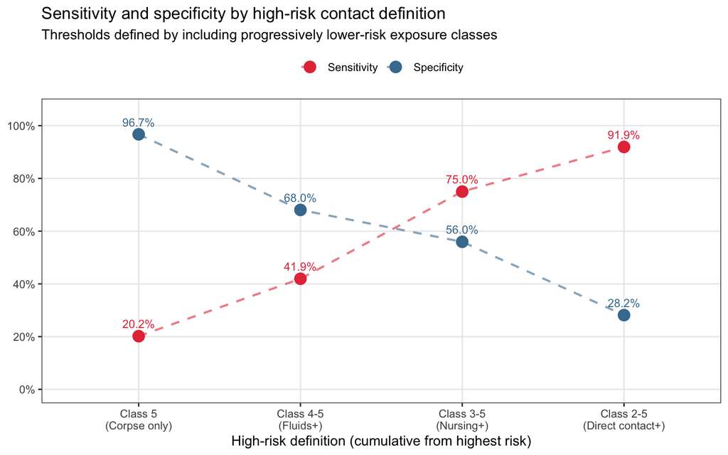

Sensitivity and specificity across high-risk contact definitions. Broadening the definition increases sensitivity but reduces specificity.

```r
all_diagnostics %>%
  dplyr::select(definition, sensitivity, specificity) %>%
  pivot_longer(
    cols      = c(sensitivity, specificity),
    names_to  = "metric",
    values_to = "value"
  ) %>%
  mutate(
    definition = factor(definition,
      levels = names(threshold_definitions),
      labels = c(
        "Class 5\n(Corpse only)",
        "Class 4-5\n(Fluids+)",
        "Class 3-5\n(Nursing+)",
        "Class 2-5\n(Direct contact+)"
      )
    ),
    metric = factor(metric,
      levels = c("sensitivity", "specificity"),
      labels = c("Sensitivity", "Specificity")
    )
  ) %>%
  ggplot(aes(x = definition, y = value, colour = metric, group = metric)) +
  geom_line(linewidth = 0.8, linetype = "dashed", alpha = 0.6) +
  geom_point(size = 4) +
  geom_text(
    aes(label = scales::percent(value, accuracy = 0.1)),
    vjust = -1, size = 3.2, show.legend = FALSE
  ) +
  scale_y_continuous(
    labels = scales::percent_format(),
    limits = c(0, 1.05),
    breaks = seq(0, 1, 0.2)
  ) +
  scale_colour_manual(values = c("Sensitivity" = "#E63946", "Specificity" = "#457B9D")) +
  labs(
    title    = "Sensitivity and specificity by high-risk contact definition",
    subtitle = "Thresholds defined by including progressively lower-risk exposure classes",
    x        = "High-risk definition (cumulative from highest risk)",
    y        = NULL,
    colour   = NULL
  ) +
  theme_bw() +
  theme(
    legend.position  = "top",
    panel.grid.minor = element_blank()
  )
```

```r
ggsave(here::here("plots", "contact_definition_diagnostics.png"),
                  dpi = 500, width = 30, height = 20, units = "cm")
```

# 11. Export

```r
write_csv(all_summaries, here::here("output", "contact_risk_summary_tables.csv"))
write_csv(all_diagnostics, here::here("output", "contact_risk_diagnostics_long.csv"))
write_csv(diagnostics_wide, here::here("output", "contact_risk_diagnostics_wide.csv"))
write_csv(line_list, here::here("output", "contact_linelist_simulation.csv"))
```